# Math 421 - Midterm

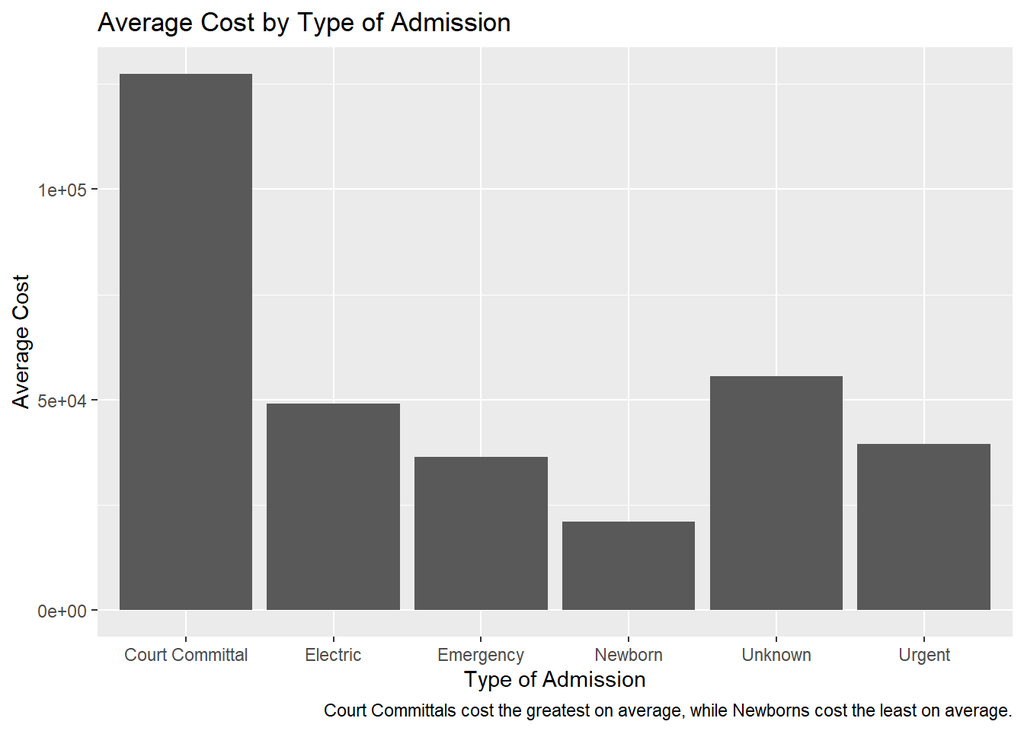

```r
df %>%
  group_by(admtype, sex) %>%
  summarise(average_tot=mean(tot, na.rm=TRUE)) %>%
  ggplot()+
  geom_col(mapping=aes(x=admtype,
                       y=average_tot
                       ),
           position = 'dodge')+
  labs(x='Type of Admission',
       y = 'Average Cost',

       title = 'Average Cost by Type of Admission',
       caption = 'Court Committals cost the greatest on average, while Newborns cost the least on average.')
```

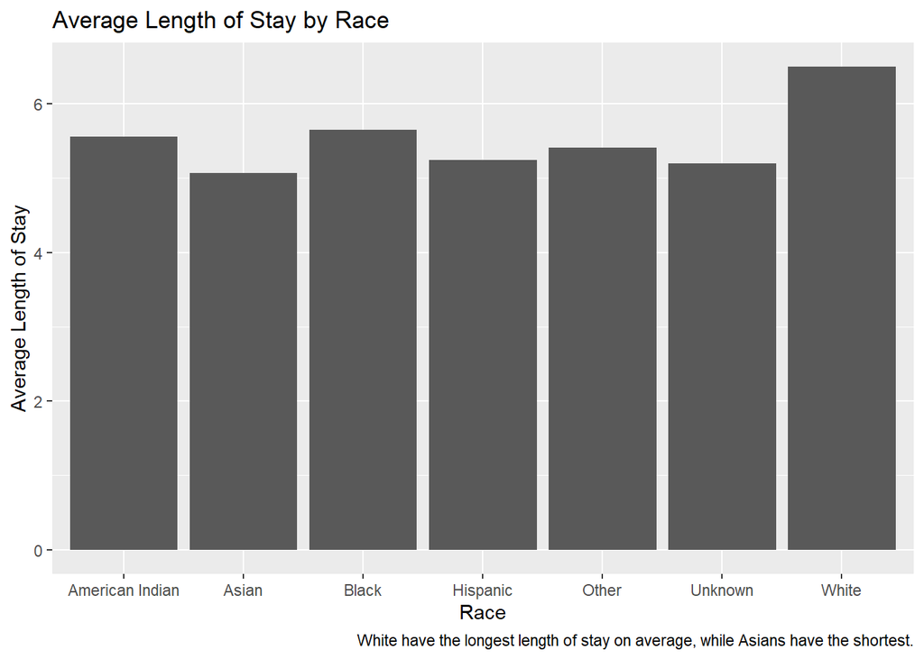

```r
df %>%
  group_by(raceethn, sex) %>%
  summarise(average_los=mean(los, na.rm=TRUE)) %>%
  ggplot()+
  geom_col(mapping=aes(x=raceethn,
                       y=average_los
                       ),
           position = 'dodge')+
  labs(x='Race',
       y = 'Average Length of Stay',

       title = 'Average Length of Stay by Race',
       caption = 'White have the longest length of stay on average, while Asians have the shortest.')
```

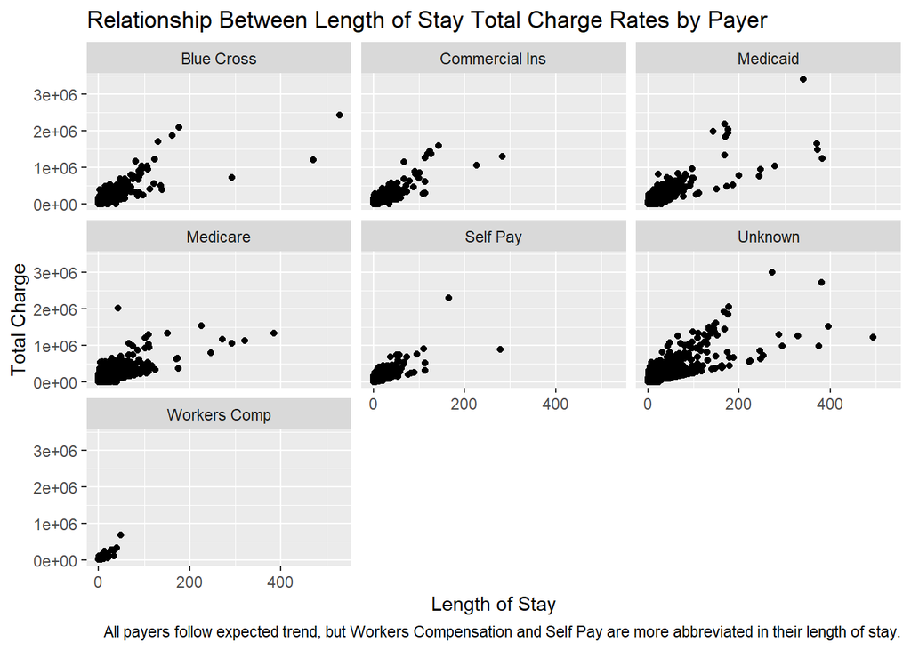

```r
df %>%
  ggplot()+
  geom_point(mapping = aes(x = los, y = tot))+
  facet_wrap(~payer)+
  labs(x='Length of Stay',
       y='Total Charge',
       title='Relationship Between Length of Stay Total Charge Rates by Payer',
       caption='All payers follow expected trend, but Workers Compensation and Self Pay are more abbreviated in their length of stay.')
```

2. Make an animation plot.

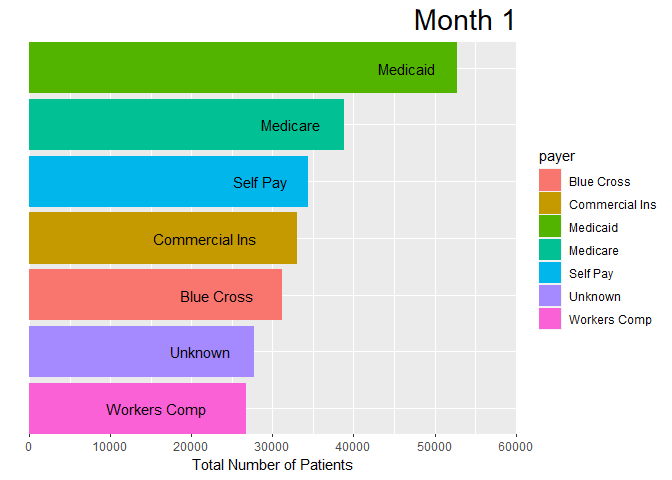

```r
library(gganimate)
library(ggplot2)
library(tidyverse)
library(lubridate)

d1 <- df %>% group_by(moa, payer) %>% summarise(mean = mean(tot))
d2 <- d1 %>% group_by(moa) %>% mutate(rank=rank(-mean))
d3 <- d2 %>% filter(rank <= 10)
a1 <- d3 %>% ggplot(aes(x=rank, y=mean, group=payer, fill=payer, label=payer)) + geom_col()+
    geom_text(aes(y = mean, label = payer), hjust = 1.4)+
    coord_flip(clip = "off", expand = FALSE) +scale_x_reverse()+
    labs(title = 'Month {closest_state}', x='', y='Total Number of Patients', fill='payer')+
    theme(plot.title = element_text(hjust = 1, size = 22),
          axis.ticks.y = element_blank(),
          axis.text.y  = element_blank()) +
    transition_states(moa)+
    ease_aes("cubic-in-out")
animate(a1, nframes = 400)
```

3. Write a paragraph to summarize the section and give your comments on the results.

## III. Predictive Models

Continue with the data from part I. Make sure you do not have any missing values in the data. Use the follows as the target and input variables:

*Target Variable*: Create the target variable taking value of

- `low` if the total charge of a patient (`tot`) is smaller than the median of the total charge, and
- `high` otherwise.

*Input Variables*:

- “age”,“sex”,“raceethn”,“provider”,“moa”,“mod”,“admtype”,“campus”, ‘los’

```r
library(dplyr)

df$target <- case_when(
  df$tot <= median(df$tot) ~ 'low',
  TRUE ~ 'high'
)

df$provider <- case_when(
  df$provider == 7201 ~ 'Newport',
  df$provider == 7202 ~ 'St. Joseph',
  df$provider == 7203 ~ 'Memorial',
  df$provider == 7204 ~ 'Miriam',
  df$provider == 7205 ~ 'Rhode Island Hospital',
  df$provider == 7206 ~ 'Roger Williams',
  df$provider == 7209 ~ 'South County',
  df$provider == 7210 ~ 'Kent County',
  df$provider == 7211 ~ 'Westerly',
  df$provider == 7212 ~ 'Rehab of RI',
  df$provider == 7213 ~ 'Landmark Medical Center',
  df$provider == 7214 ~ 'Women and Infants',
  df$provider == 7215 ~ 'Bradley',
  TRUE ~ 'Butler'
)


df$campus <- case_when(
  df$campus == 0 ~ 'Hospital Has Only One Premise',
  df$campus == 1 ~ 'St. Joseph Health Services of Rhode Island - Our Lady of Fatima Hospital',
  df$campus == 2 ~ 'St. Joseph Health Services of Rhode Island - St. Joseph Hospital for Specialty Care',
  df$campus == 3 ~ 'Rhode Island Hospital - Adult',
  TRUE ~ 'Rhode Island Hospital - Hasbro'
)

df2 <- df %>% select("target", "age", "sex", "raceethn", "provider", "moa", "mod", "admtype", "campus", "los")
```

1. Use `filter` function to filter out rows where `raceethn==''` or `admtype==''`. Make sure all the categorical variables are factor, numeric variables are numeric. Set Training : Testing Split = 10 : 90

```r
library(caret)

df2 <- df2 %>%
  filter(raceethn!='',admtype!='') %>%
  mutate(target=as.factor(target),
         age=age,
         sex=as.factor(sex),
         raceethn=as.factor(raceethn),
         provider=as.factor(provider),
         moa=moa,
         mod=mod,
         admtype=as.factor(admtype),
         campus=as.factor(campus),
         los=los)

set.seed(2020)
splitIndex <- createDataPartition(df2$target, p = .1,
                                  list = FALSE)

df_train <- df2[ splitIndex,]
df_test <- df2[-splitIndex,]
```

2. Train a decision tree using `rpart`. Plot the decision tree. Plot the variable importance ranked by the tree.

```r
library(rattle)
library(rpart)

tree_model <- rpart(target ~ ., data = df_train,
                    control = rpart.control(maxdepth = 3))
pred <- predict(tree_model, df_test, type = "class")
cm <- confusionMatrix(data = pred, reference = df_test$target, positive = "low")
cm$overall[1]
```

```
##  Accuracy
## 0.8146877
```

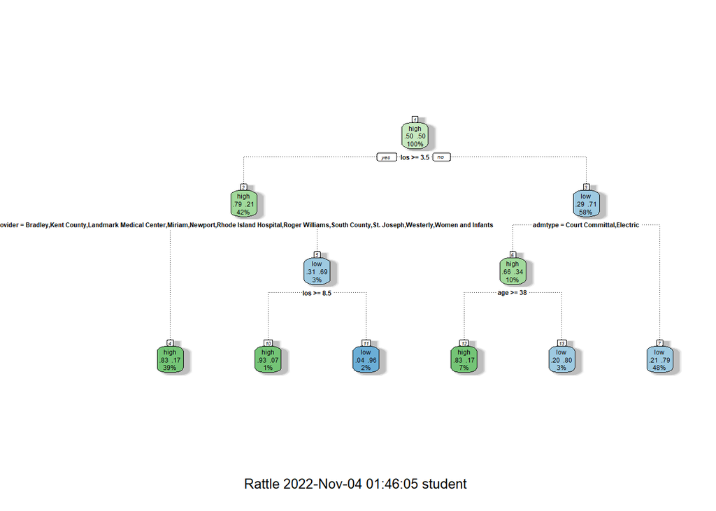

```r
fancyRpartPlot(tree_model)
```

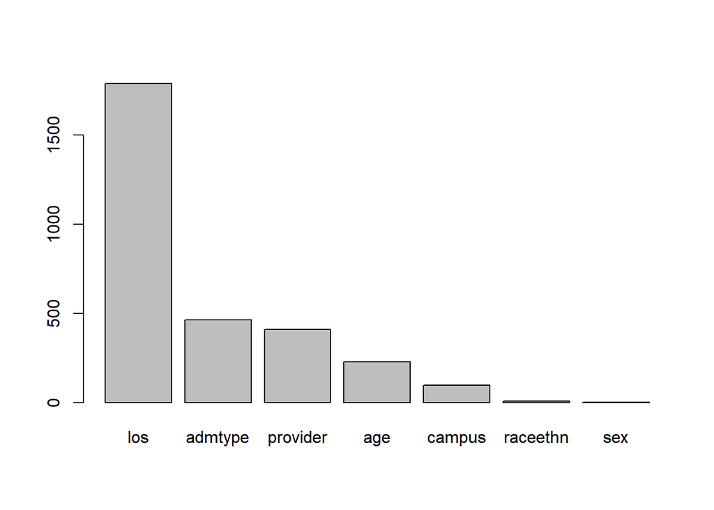

```r
barplot(tree_model$variable.importance)
```

3. Using caret for this question. Set `Training Control` to be: Use Cross-Validation of 5 folds across all models. Train & tune at least 2 different models (i.e. two different values for `method=` in the train function of caret). Plot the hyper-parameter tuning plots for each model.

```r
library(mlbench)
trControl = trainControl(method = "cv",
                         number = 5)

tuneGrid = expand.grid(mtry = 2:4,
                       splitrule = c('gini', 'extratrees'),
                       min.node.size = c(1:10))

Model2 <- train(target~., data=df_train,
                method = "rpart1SE",
                maxdepth=5)
predSecond <- predict(Model2, df_test)
cmSecond <- confusionMatrix(data = predSecond, reference = df_test$target)
cmSecond$overall[1]
```

```
##  Accuracy
## 0.8139779
```

```r
Model1 <- train(target~., data=df_train,
                method = "glmnet",
                maxdepth=5)
predFirst <- predict(Model1, df_test)
cmFirst <- confusionMatrix(data = predFirst, reference = df_test$target)
cmFirst$overall[1]
```

```
## Accuracy
## 0.812744
```

4. Plot the comparison of the models in 3.

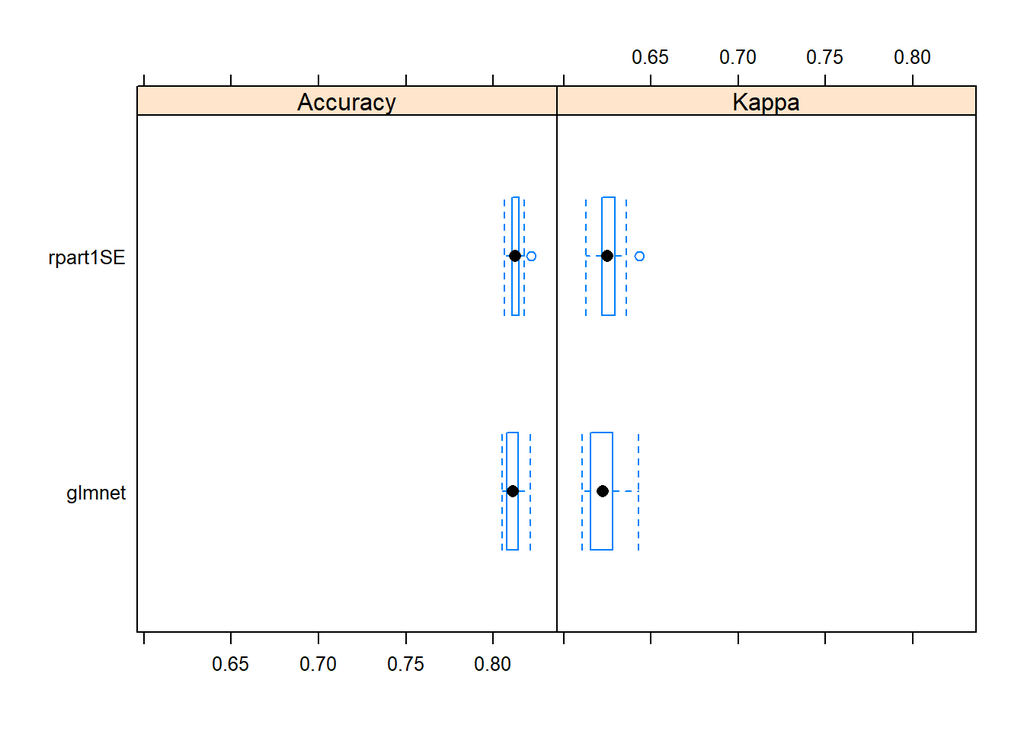

```r
results <- resamples(list('glmnet' = Model1,
                          'rpart1SE' = Model2
                          ))
bwplot(results)
```

5. What is your final selection for the model? Test the accuracy of your final model on the test data.

```r
predFinal <- predict(Model2, df_test)

cmFinal <- confusionMatrix(data = predFinal, reference = df_test$target, positive = "low")

cmFinal$overall[1]
```

```
##  Accuracy
## 0.8139779
```

6. Create another `target` variable (binary), decide the input variables and redo 1 to 5.

```r
df <- read_sas('C:/Users/student/OneDrive - Bryant University/Documents/R/Math421/hdd0318cy.sas7bdat')
df <- df %>% filter(yod==18)
df <- df %>% select(-payfix, -preopday, -obs_hour, -nicu_day)
df$sex <- case_when(
    df$sex==1 ~ 'Male',
    df$sex==2 ~ 'Female',
    TRUE ~ 'Unknown'
  )

df$raceethn <- case_when(
    df$raceethn==1 ~ 'White',
    df$raceethn==2 ~ 'Black',
    df$raceethn==3 ~ 'Asian',
    df$raceethn==4 ~ 'American Indian',
    df$raceethn==5 ~ 'Native Hawaiian',
    df$raceethn==6 ~ 'Other',
    df$raceethn==7 ~ 'Hispanic',
    TRUE ~ 'Unknown'
  )

df$admtype <- case_when(
    df$admtype==1 ~ 'Emergency',
    df$admtype==2 ~ 'Urgent',
    df$admtype==3 ~ 'Electric',
    df$admtype==4 ~ 'Newborn',
    df$admtype==5 ~ 'Court Committal',
    TRUE ~ 'Unknown'
  )

df$payer <- case_when(
    df$payer==0 ~ 'Medicare',
    df$payer==1 ~ 'Medicaid',
    df$payer==4 ~ 'Workers Comp',
    df$payer==5 ~ 'Blue Cross',
    df$payer==6 ~ 'Commercial Ins',
    df$payer==7 ~ 'Self Pay',
    TRUE ~ 'Unknown'
  )

df$dispub92 <- case_when(
    df$dispub92==01 ~ 'Self Care',
    df$dispub92==02 ~ 'Short Term Hosp',
    df$dispub92==03 ~ 'Nursing Fac',
    df$dispub92==04 ~ 'ICF',
    TRUE ~ 'Unknown'

)

df$target <- case_when(
  df$los <= median(df$los) ~ 'low',
  TRUE ~ 'high'
)

df$provider <- case_when(
  df$provider == 7201 ~ 'Newport',
  df$provider == 7202 ~ 'St. Joseph',
  df$provider == 7203 ~ 'Memorial',
  df$provider == 7204 ~ 'Miriam',
  df$provider == 7205 ~ 'Rhode Island Hospital',
  df$provider == 7206 ~ 'Roger Williams',
  df$provider == 7209 ~ 'South County',
  df$provider == 7210 ~ 'Kent County',
  df$provider == 7211 ~ 'Westerly',
  df$provider == 7212 ~ 'Rehab of RI',
  df$provider == 7213 ~ 'Landmark Medical Center',
  df$provider == 7214 ~ 'Women and Infants',
  df$provider == 7215 ~ 'Bradley',
  TRUE ~ 'Butler'
)


df$campus <- case_when(
  df$campus == 0 ~ 'Hospital Has Only One Premise',
  df$campus == 1 ~ 'St. Joseph Health Services of Rhode Island - Our Lady of Fatima Hospital',
  df$campus == 2 ~ 'St. Joseph Health Services of Rhode Island - St. Joseph Hospital for Specialty Care',
  df$campus == 3 ~ 'Rhode Island Hospital - Adult',
  TRUE ~ 'Rhode Island Hospital - Hasbro'
)

df2 <- df %>% select("target", "age", "sex", "raceethn", "provider", "moa", "mod", "admtype", "campus", "tot")

df2 <- df2 %>%
  filter(raceethn!='',admtype!='') %>%
  mutate(target=as.factor(target),
         age=age,
         sex=as.factor(sex),
         raceethn=as.factor(raceethn),
         provider=as.factor(provider),
         moa=moa,
         mod=mod,
         admtype=as.factor(admtype),
         campus=as.factor(campus),
         )

set.seed(2020)
splitIndex <- createDataPartition(df2$target, p = .1,
                                  list = FALSE)

df_train <- df2[ splitIndex,]
df_test <- df2[-splitIndex,]

tree_model <- rpart(target ~ ., data = df_train,
                    control = rpart.control(maxdepth = 3))
pred <- predict(tree_model, df_test, type = "class")
cm <- confusionMatrix(data = pred, reference = df_test$target, positive = "low")
cm$overall[1]
```

```
##  Accuracy
## 0.7964827
```

[figure not shown]

```r
fancyRpartPlot(tree_model)
```

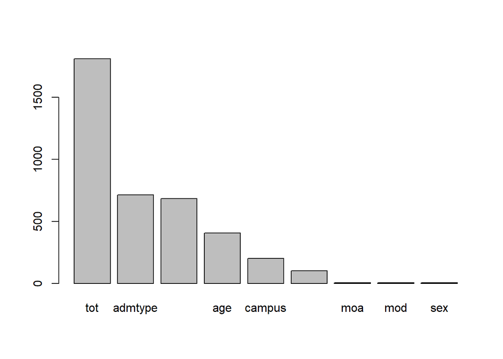

```r
barplot(tree_model$variable.importance)
```

```r
trControl = trainControl(method = "cv",
                         number = 5)

tuneGrid = expand.grid(mtry = 2:4,
                       splitrule = c('gini', 'extratrees'),
                       min.node.size = c(1:10))

Model2 <- train(target~., data=df_train,
                method = "rpart1SE",
                maxdepth=5)
predSecond <- predict(Model2, df_test)
cmSecond <- confusionMatrix(data = predSecond, reference = df_test$target)
cmSecond$overall[1]
```

```
##  Accuracy
## 0.7951305
```

```r
Model1 <- train(target~., data=df_train,
                method = "glmnet",
                maxdepth=5)
predFirst <- predict(Model1, df_test)
cmFirst <- confusionMatrix(data = predFirst, reference = df_test$target)
cmFirst$overall[1]
```

```
##  Accuracy
## 0.7814652
```

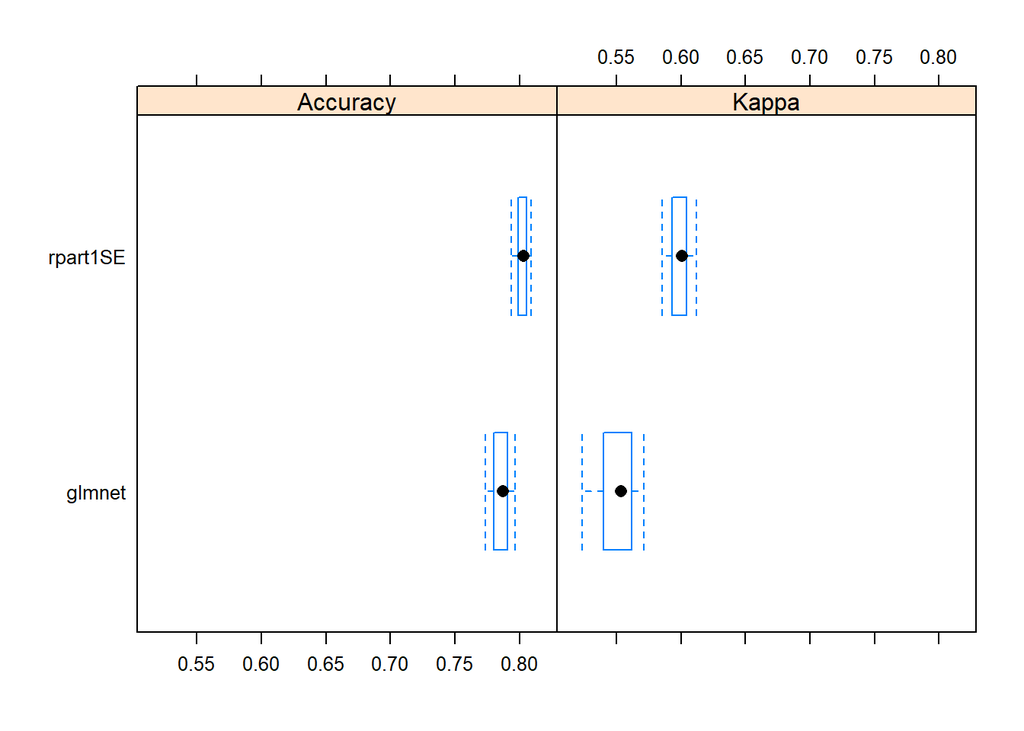

```r
results <- resamples(list('glmnet' = Model1,
                          'rpart1SE' = Model2
                          ))
bwplot(results)
```

```r
predFinal <- predict(Model2, df_test)

cmFinal <- confusionMatrix(data = predFinal, reference = df_test$target, positive = "low")

cmFinal$overall[1]
```

```
##  Accuracy
## 0.7951305
```

7. Write a paragraph to summarize the section and give your comments on the results.